# BildAktVR data analysis 1

Ondrej Havlicek

ohavlicek@gmail.com 11/2017

# Analysis 1 is re-arranged and extended in Analysis 2, please see that instead

This file is here for historic comparisons only, some email correspondence refers to this analysis.

## Exploratory analysis

### Explore a bit scenes distribution and randomization

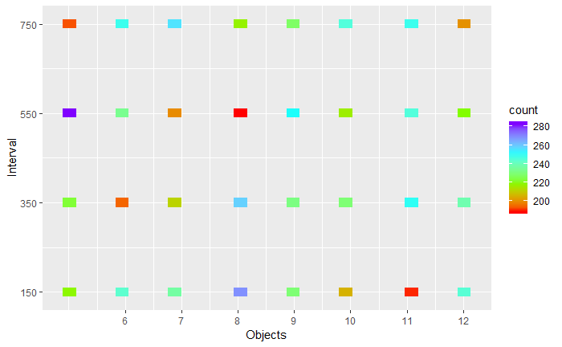

Number of objects inside a scene is not orthogonal to time interval: some combinations appear often, some less often. We will have to revise the VR code.

### Objects error exploration

Distributions of object estimation errors (error = estimated - actual) for each participant:

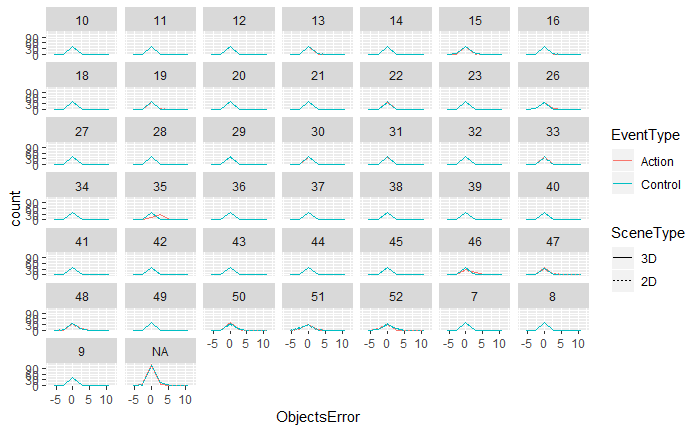

People are mostly correct about the object count.

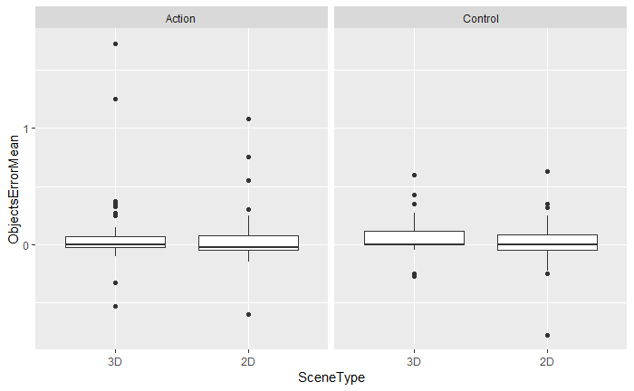

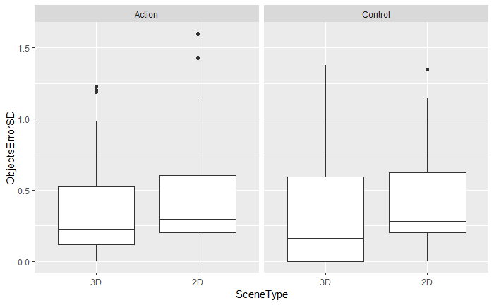

Precision is also better for 3D than for 2D scenes

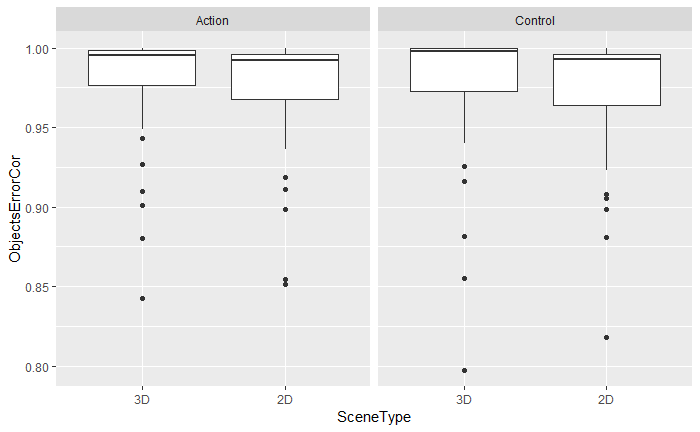

There is also a difference in correlation between actual and estimated number of objects, but very tiny.